# Domain Shift, Transfer Learning, and Model Recalibration

Biostat 274

Author

Dr. Jin Zhou @ UCLA

Published

March 4, 2026

Credit: This note draws from

- Huang et al. (2020). [*A tutorial on calibration measurements and calibration models for clinical prediction models*](https://doi.org/10.1093/jamia/ocz228). *JAMIA*, 27(4), 621–633.
- Van Calster et al. (2016). A calibration hierarchy for risk models. *J Clin Epidemiol*, 74, 167–176.
- Janssen et al. (2008). Updating methods improved the performance of a clinical prediction model. *J Clin Epidemiol*, 61(1), 76–86.
- Kouw & Loog (2018). [*An Introduction to Domain Adaptation and Transfer Learning*](https://arxiv.org/abs/1812.11806).

## 1 Motivation

### 1.1 The Core Problem

- Models built on one population often fail **silently** when applied to another.
- “Silently” means AUROC looks fine — but predicted probabilities are wrong.
- Wrong probabilities lead to wrong clinical decisions.

### 1.2 Two Clinical Stakes

**Dementia risk prediction:** At a predicted risk of 40%, observed incidence was only 10% — a 4× overestimation. Patients referred for unnecessary workup.

**Cardiovascular risk / statin prescribing:** ACC/AHA guidelines recommend statins for patients with risk **> 7.5%**. A miscalibrated model assigning 8% to a patient whose true risk is 4% triggers unnecessary treatment — and vice versa.

### 1.3 Discrimination vs. Calibration

|  | What it measures | Metric |
| --- | --- | --- |
| **Discrimination** | Can the model *rank* patients by risk? | AUROC |
| **Calibration** | Are the predicted probabilities *numerically correct*? | Reliability diagram, ECE, ICI |

- These are **independent.** A model can discriminate perfectly and be grossly miscalibrated.
- 63% of published clinical prediction models report discrimination. Only **36% report calibration** (Van Calster et al., 2019).

### 1.4 The Calibration Hierarchy

| Level | Question |
| --- | --- |
| **Mean calibration** | Does average predicted probability = observed event rate? |
| **Weak calibration** | Is calibration slope = 1 and intercept = 0? |
| **Moderate calibration** | Within risk subgroups, do predicted and observed rates agree? |
| **Strong calibration** | For every individual, does predicted probability = true probability? |

Most clinical work focuses on levels 1–3. Strong calibration is rarely achievable.

## 2 Simulated Data Setup

All examples use the same dataset. **Run this chunk first** — all subsequent sections depend on these objects.

```r
library(tidyverse)
library(tidymodels)
library(ResourceSelection)
library(patchwork)

set.seed(274)

# ── Simulate data (mirroring Huang et al. 2020) ──────────────────────────────
n         <- 2000
x1        <- rnorm(n); x2 <- rnorm(n); x3 <- rbinom(n, 1, 0.4)
log_odds  <- -2 + 0.8*x1 + 0.6*x2 + 0.5*x3
true_prob <- plogis(log_odds)
y         <- rbinom(n, 1, true_prob)

# 60% train / 20% calibration / 20% test
idx       <- sample(1:n)
train_idx <- idx[1:1200]
test_idx  <- idx[1601:2000]

df       <- tibble(y, x1, x2, x3)
df_train <- df[train_idx, ]
df_test  <- df[test_idx, ]
y_test   <- df_test$y

# ── Fit logistic regression on training set ───────────────────────────────────
lr_fit <- glm(y ~ x1 + x2 + x3, data = df_train, family = binomial)
p_lr   <- predict(lr_fit, newdata = df_test, type = "response")

# ── Three models for discrimination vs. calibration demo ─────────────────────
p_A <- p_lr                          # Model A: original LR — well calibrated
p_B <- p_lr / 10                     # Model B: divided by 10 — grossly miscalibrated
p_C <- plogis(qlogis(p_lr) * 1.5)   # Model C: rescaled toward extremes

# ── Well-calibrated vs. miscalibrated (SVM-like) ─────────────────────────────
p_well <- p_A
p_misc <- plogis(qlogis(p_A) * 0.3 - 1.5)  # compressed + shifted (mimics SVM)

# ── Helper functions ──────────────────────────────────────────────────────────
auroc <- function(pred, truth) {
  roc_auc(tibble(truth = factor(truth, levels = c("1","0")), prob = pred),
          truth, prob)$.estimate
}

make_cal_df <- function(pred, truth, label) {
  tibble(pred = pred, truth = truth) %>%
    mutate(bin = cut(pred, breaks = seq(0, 1, 0.1), include.lowest = TRUE)) %>%
    group_by(bin) %>%
    summarise(mean_pred = mean(pred), mean_obs = mean(truth),
              n = n(), .groups = "drop") %>%
    mutate(model = label)
}

cx_int <- function(p, y) {
  lp <- qlogis(pmin(pmax(p, 1e-6), 1-1e-6))
  coef(glm(y ~ offset(lp), family = binomial))[["(Intercept)"]]
}

cx_slp <- function(p, y) {
  lp <- qlogis(pmin(pmax(p, 1e-6), 1-1e-6))
  coef(glm(y ~ lp, family = binomial))[["lp"]]
}

ici_fn <- function(pred, truth) {
  df <- tibble(pred, truth) %>% arrange(pred)
  mean(abs(df$pred - predict(loess(truth ~ pred, data = df, span = 0.75), newdata = df)))
}

cat("Event rate in test set:         ", round(mean(y_test), 3), "\n")
```

```
Event rate in test set:          0.192
```

```r
cat("Mean predicted (well-calibrated):", round(mean(p_well), 3), "\n")
```

```
Mean predicted (well-calibrated): 0.185
```

```r
cat("Mean predicted (miscalibrated):  ", round(mean(p_misc), 3), "\n")
```

```
Mean predicted (miscalibrated):   0.118
```

## 3 Discrimination vs. Calibration: Demo

Three models with **identical AUROC** but dramatically different calibration — reproducing Figure 1 from Huang et al. (2020).

```r
cat(sprintf("AUROC  A (original):      %.3f\n", auroc(p_A, y_test)))
```

```
AUROC  A (original):      0.732
```

```r
cat(sprintf("AUROC  B (divided by 10): %.3f\n", auroc(p_B, y_test)))
```

```
AUROC  B (divided by 10): 0.732
```

```r
cat(sprintf("AUROC  C (rescaled):      %.3f\n", auroc(p_C, y_test)))
```

```
AUROC  C (rescaled):      0.732
```

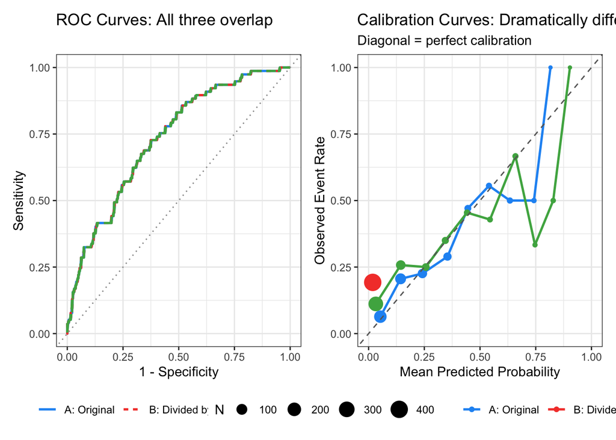

Figure 1: All three models have the same AUROC. ROC curves overlap. Calibration curves diverge completely.

```r
roc_df <- bind_rows(
  roc_curve(tibble(truth=factor(y_test,levels=c("1","0")), prob=p_A), truth, prob) %>%
    mutate(model="A: Original"),
  roc_curve(tibble(truth=factor(y_test,levels=c("1","0")), prob=p_B), truth, prob) %>%
    mutate(model="B: Divided by 10"),
  roc_curve(tibble(truth=factor(y_test,levels=c("1","0")), prob=p_C), truth, prob) %>%
    mutate(model="C: Rescaled")
)

p_roc <- ggplot(roc_df, aes(x=1-specificity, y=sensitivity, color=model, linetype=model)) +
  geom_line(linewidth=0.9) +
  geom_abline(linetype="dotted", color="gray60") +
  scale_color_manual(values=c("#2196F3","#F44336","#4CAF50")) +
  labs(title="ROC Curves: All three overlap",
       x="1 - Specificity", y="Sensitivity", color=NULL, linetype=NULL) +
  theme_bw() + theme(legend.position="bottom")

cal_all <- bind_rows(
  make_cal_df(p_A, y_test, "A: Original"),
  make_cal_df(p_B, y_test, "B: Divided by 10"),
  make_cal_df(p_C, y_test, "C: Rescaled")
)

p_cal <- ggplot(cal_all, aes(x=mean_pred, y=mean_obs, color=model)) +
  geom_line(linewidth=0.9) + geom_point(aes(size=n)) +
  geom_abline(slope=1, intercept=0, linetype="dashed", color="gray40") +
  scale_color_manual(values=c("#2196F3","#F44336","#4CAF50")) +
  scale_x_continuous(limits=c(0,1)) + scale_y_continuous(limits=c(0,1)) +
  labs(title="Calibration Curves: Dramatically different",
       subtitle="Diagonal = perfect calibration",
       x="Mean Predicted Probability", y="Observed Event Rate", color=NULL, size="N") +
  theme_bw() + theme(legend.position="bottom")

p_roc + p_cal
```

## 4 Calibration Metrics

### 4.1 Brier Score

Mean squared error between predicted probabilities and binary outcomes:

$$\text{Brier} = \frac{1}{N}\sum_{i=1}^{N}(\hat{p}_i - y_i)^2$$

- Range: 0 (perfect) to 1. Null model (always predict mean) ≈ 0.25 at 50% prevalence.
- **Combined measure** — mixes calibration and discrimination.

```r
brier_well <- mean((p_well - y_test)^2)
brier_misc <- mean((p_misc - y_test)^2)

cat(sprintf("Brier — Well-calibrated: %.4f\n", brier_well))
```

```
Brier — Well-calibrated: 0.1392
```

```r
cat(sprintf("Brier — Miscalibrated:   %.4f\n", brier_misc))
```

```
Brier — Miscalibrated:   0.1525
```

```r
cat(sprintf("Null model:              %.4f\n", mean((mean(y_test) - y_test)^2)))
```

```
Null model:              0.1554
```

### 4.2 Spiegelhalter Z-Test

Isolates the calibration component of the Brier score:

$$Z = \frac{\sum(y_i - \hat{p}_i)(1 - 2\hat{p}_i)}{\sqrt{\sum(1-2\hat{p}_i)^2 \hat{p}_i(1-\hat{p}_i)}}$$

- $|Z| > 1.96$: significant miscalibration at $\alpha = 0.05$.
- More targeted than Brier — tests calibration specifically.

```r
spieg_z <- function(pred, truth) {
  num   <- sum((truth - pred) * (1 - 2*pred))
  denom <- sqrt(sum((1 - 2*pred)^2 * pred * (1 - pred)))
  z     <- num / denom
  p     <- 2 * pnorm(-abs(z))
  cat(sprintf("  Z = %.3f  |  p = %.4f  |  %s\n", z, p,
              ifelse(abs(z) > 1.96, "MISCALIBRATED", "OK")))
}

cat("Well-calibrated:\n"); spieg_z(p_well, y_test)
```

```
Well-calibrated:
```

```
  Z = 1.455  |  p = 0.1457  |  OK
```

```r
cat("Miscalibrated:\n");   spieg_z(p_misc, y_test)
```

```
Miscalibrated:
```

```
  Z = 4.167  |  p = 0.0000  |  MISCALIBRATED
```

### 4.3 Hosmer-Lemeshow Test

Group patients into $g$ bins (typically deciles), compare expected vs. observed events per bin:

$$\text{HL} = \sum_{k=1}^{g}\left[\frac{(O_{k,1}-E_{k,1})^2}{E_{k,1}} + \frac{(O_{k,0}-E_{k,0})^2}{E_{k,0}}\right] \sim \chi^2_{g-2}$$

- $p < 0.05$: significant miscalibration
- **Limitation:** Overpowered in large samples — may reject for trivial deviations.

```r
hl_well <- hoslem.test(y_test, p_well, g = 10)
hl_misc <- hoslem.test(y_test, p_misc, g = 10)

cat(sprintf("Well-calibrated: X2 = %.2f, p = %.4f  %s\n",
            hl_well$statistic, hl_well$p.value,
            ifelse(hl_well$p.value < 0.05, "MISCALIBRATED", "OK")))
```

```
Well-calibrated: X2 = 8.58, p = 0.3786  OK
```

```r
cat(sprintf("Miscalibrated:   X2 = %.2f, p = %.4f  %s\n",
            hl_misc$statistic, hl_misc$p.value,
            ifelse(hl_misc$p.value < 0.05, "MISCALIBRATED", "OK")))
```

```
Miscalibrated:   X2 = 48.12, p = 0.0000  MISCALIBRATED
```

### 4.4 Reliability Diagram (Calibration Curve)

Plot mean predicted probability vs. observed event rate per bin. Perfect calibration = 45° diagonal.

- Above diagonal → model **underestimates** risk
- Below diagonal → model **overestimates** risk

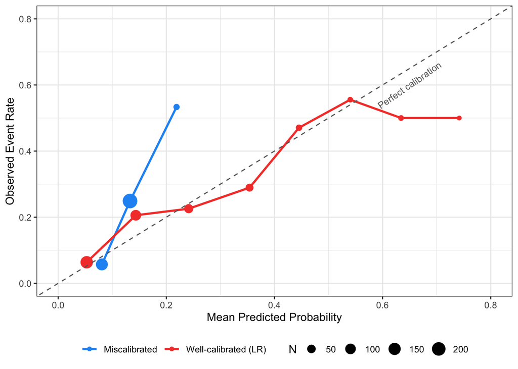

```r
ggplot(bind_rows(make_cal_df(p_well, y_test, "Well-calibrated (LR)"),
                 make_cal_df(p_misc, y_test, "Miscalibrated")),
       aes(x=mean_pred, y=mean_obs, color=model)) +
  geom_line(linewidth=1.0) + geom_point(aes(size=n)) +
  geom_abline(slope=1, intercept=0, linetype="dashed", color="gray40") +
  annotate("text", x=0.65, y=0.60, label="Perfect calibration",
           color="gray40", size=3.2, angle=35) +
  scale_color_manual(values=c("#2196F3","#F44336")) +
  scale_x_continuous(limits=c(0,0.8)) + scale_y_continuous(limits=c(0,0.8)) +
  labs(x="Mean Predicted Probability", y="Observed Event Rate", color=NULL, size="N") +
  theme_bw() + theme(legend.position="bottom")
```

### 4.5 ECE and MCE

Scalar summaries of miscalibration — popular in machine learning:

$$\text{ECE} = \sum_k P(k)|o_k - e_k| \qquad \text{MCE} = \max_k |o_k - e_k|$$

- ECE = weighted average error across bins; MCE = worst-case bin error.
- No formal test — threshold is context-dependent.

**NoteML connection: ECE and MCE**

ECE and MCE come from the ML literature (Guo et al., ICML 2017) and appear constantly in deep learning papers. They are the scalar version of the reliability diagram — same bins, same logic, just summarized as a single number instead of a plot. If you read a paper reporting ECE on a neural network, it is measuring exactly what you learned here.

```r
ece_mce <- function(pred, truth, K = 10) {
  bins <- cut(pred, breaks=seq(0,1,length.out=K+1), include.lowest=TRUE)
  tibble(pred, truth, bins) %>%
    group_by(bins) %>%
    summarise(ep=mean(pred), eo=mean(truth), n=n(), .groups="drop") %>%
    summarise(ECE=sum(n/sum(n)*abs(ep-eo), na.rm=TRUE),
              MCE=max(abs(ep-eo), na.rm=TRUE))
}

ece_well <- ece_mce(p_well, y_test)
ece_misc <- ece_mce(p_misc, y_test)

cat(sprintf("Well-calibrated: ECE = %.4f | MCE = %.4f\n", ece_well$ECE, ece_well$MCE))
```

```
Well-calibrated: ECE = 0.0364 | MCE = 0.2418
```

```r
cat(sprintf("Miscalibrated:   ECE = %.4f | MCE = %.4f\n", ece_misc$ECE, ece_misc$MCE))
```

```
Miscalibrated:   ECE = 0.0912 | MCE = 0.3144
```

### 4.6 Calibration Intercept and Slope

Regress the binary outcome on the log-odds of the predicted probability:

$$\text{logit}\{P(Y=1)\} = \alpha + \beta \cdot \text{logit}(\hat{p})$$

| Parameter | Ideal | If off |
| --- | --- | --- |
| Intercept $\alpha$ | 0 | $< 0$: overestimation; $> 0$: underestimation |
| Slope $\beta$ | 1 | $< 1$: predictions too extreme; $> 1$: too conservative |

**NoteML connection: Platt scaling**

In machine learning, this two-parameter logistic fit is called **Platt scaling** (Platt, 1999). Same equation, different name. When you see “Platt scaling” in an sklearn or PyTorch tutorial, it is fitting exactly this model — `glm(y ~ logit_p, family = binomial)` — on a held-out calibration set.

```r
cal_stats <- function(pred, truth, label) {
  lp    <- qlogis(pmin(pmax(pred, 1e-6), 1-1e-6))
  m_int <- glm(truth ~ offset(lp), family=binomial)
  m_slp <- glm(truth ~ lp, family=binomial)
  cat(sprintf("\n%s\n  Intercept alpha = %.3f  [ideal 0]\n  Slope     beta  = %.3f  [ideal 1]\n",
              label, coef(m_int)[["(Intercept)"]], coef(m_slp)[["lp"]]))
}

cal_stats(p_well, y_test, "Well-calibrated model")
```

```
Well-calibrated model
  Intercept alpha = 0.062  [ideal 0]
  Slope     beta  = 0.772  [ideal 1]
```

```r
cal_stats(p_misc, y_test, "Miscalibrated model")
```

```
Miscalibrated model
  Intercept alpha = 0.589  [ideal 0]
  Slope     beta  = 2.574  [ideal 1]
```

### 4.7 Integrated Calibration Index (ICI)

Loess-smoothed version of the calibration curve, summarized as a scalar:

$$\text{ICI} = \frac{1}{N}\sum_{i=1}^{N}|\hat{p}_i - \hat{f}(\hat{p}_i)|$$

where $\hat{f}$ is a Loess smoother fitted to $(\hat{p}_i, y_i)$.

- Detects regional miscalibration that slope/intercept miss.
- ICI near 0 = well calibrated.

```r
cat(sprintf("ICI — Well-calibrated: %.4f\n", ici_fn(p_well, y_test)))
```

```
ICI — Well-calibrated: 0.0354
```

```r
cat(sprintf("ICI — Miscalibrated:   %.4f\n", ici_fn(p_misc, y_test)))
```

```
ICI — Miscalibrated:   0.0902
```

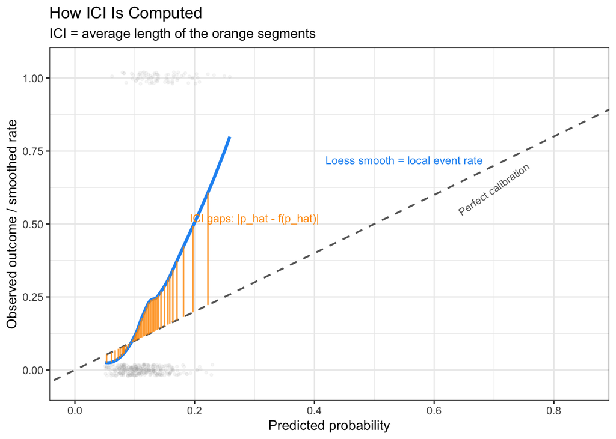

Figure 3: ICI visualized. The Loess curve (blue) is fitted directly to the raw 0/1 outcomes — at each predicted probability it estimates the local event rate. The orange segments are the gaps |p_hat - f(p_hat)| for a sample of patients. ICI is the average length of those segments.

```r
# ── Fit Loess to raw outcomes ─────────────────────────────────────────────────
df_ici <- tibble(pred = p_misc, truth = y_test) %>% arrange(pred)
loess_fit <- loess(truth ~ pred, data = df_ici, span = 0.75)
df_ici$smooth <- predict(loess_fit, newdata = df_ici)

# ── Sample ~40 evenly-spaced points to draw ICI segments ─────────────────────
set.seed(7)
samp <- df_ici %>%
  mutate(gap = abs(pred - smooth)) %>%
  slice(round(seq(5, n() - 5, length.out = 40)))

ggplot() +
  # raw 0/1 outcomes as jittered background points
  geom_jitter(data = df_ici, aes(x = pred, y = truth),
              height = 0.02, alpha = 0.08, size = 0.8, color = "gray60") +
  # perfect calibration diagonal
  geom_abline(slope = 1, intercept = 0, linetype = "dashed",
              color = "gray40", linewidth = 0.7) +
  # Loess smooth curve
  geom_line(data = df_ici, aes(x = pred, y = smooth),
            color = "#2196F3", linewidth = 1.2) +
  # ICI gap segments
  geom_segment(data = samp,
               aes(x = pred, xend = pred, y = pred, yend = smooth),
               color = "#FF9800", linewidth = 0.6, alpha = 0.8) +
  # annotation
  annotate("text", x = 0.55, y = 0.72, color = "#2196F3", size = 3.2,
           label = "Loess smooth = local event rate") +
  annotate("text", x = 0.30, y = 0.52, color = "#FF9800", size = 3.2,
           label = "ICI gaps: |p_hat - f(p_hat)|") +
  annotate("text", x = 0.70, y = 0.62, color = "gray40", size = 3.0,
           label = "Perfect calibration", angle = 35) +
  scale_x_continuous(limits = c(0, 0.85), name = "Predicted probability") +
  scale_y_continuous(limits = c(-0.05, 1.05), name = "Observed outcome / smoothed rate") +
  labs(title = "How ICI Is Computed",
       subtitle = "ICI = average length of the orange segments") +
  theme_bw()
```

### 4.8 All Metrics: Summary Table

```r
tibble(
  Metric      = c("AUROC", "Brier Score", "H-L p-value",
                  "Cal. Intercept (alpha)", "Cal. Slope (beta)",
                  "ECE", "MCE", "ICI"),
  `Well-cal.` = c(auroc(p_well, y_test), brier_well, hl_well$p.value,
                  cx_int(p_well, y_test), cx_slp(p_well, y_test),
                  ece_well$ECE, ece_well$MCE, ici_fn(p_well, y_test)) %>% round(4),
  `Miscal.`   = c(auroc(p_misc, y_test), brier_misc, hl_misc$p.value,
                  cx_int(p_misc, y_test), cx_slp(p_misc, y_test),
                  ece_misc$ECE, ece_misc$MCE, ici_fn(p_misc, y_test)) %>% round(4),
  `Ideal`     = c("higher", "0", "> 0.05", "0", "1", "0", "0", "0")
) %>% knitr::kable(align=c("l","r","r","c"))
```

Table 1: Mirrors Table 2 in Huang et al. (2020). AUROC is nearly identical — it misses the miscalibration entirely.

| Metric | Well-cal. | Miscal. | Ideal |
| --- | --- | --- | --- |
| AUROC | 0.7320 | 0.7320 | higher |
| Brier Score | 0.1392 | 0.1525 | 0 |
| H-L p-value | 0.3786 | 0.0000 | > 0.05 |
| Cal. Intercept (alpha) | 0.0616 | 0.5887 | 0 |
| Cal. Slope (beta) | 0.7722 | 2.5741 | 1 |
| ECE | 0.0364 | 0.0912 | 0 |
| MCE | 0.2418 | 0.3144 | 0 |
| ICI | 0.0354 | 0.0902 | 0 |

### 4.9 Metric Comparison

| Metric | Strength | Weakness |
| --- | --- | --- |
| Brier score | Easy to compute | Mixes discrimination + calibration |
| Spiegelhalter Z | Formal test, isolates calibration | Less intuitive |
| Hosmer-Lemeshow | Most widely cited | Overpowered at large $n$; bin choice arbitrary |
| Reliability diagram | Shows *where* miscalibration occurs | Not continuous between points |
| ECE / MCE | Intuitive, ML-friendly | No formal test |
| Cal. intercept + slope | No binning; quantifies direction | Misses cancelling regional errors |
| ICI | Catches regional errors | Needs Loess bandwidth choice |

> **Practical recommendation:** Reliability diagram + Spiegelhalter Z or H-L + ICI. Report intercept and slope to characterize direction.

## 5 Domain Shift: When Recalibration Is Needed

Measuring miscalibration tells you *that* something is wrong. Understanding **why** tells you which fix to apply.

### 5.1 Taxonomy of Distribution Shift

| Shift type | What changes | What stays the same |
| --- | --- | --- |
| **Covariate shift** | $P(X)$ — patient mix | $P(Y \mid X)$ — disease process |
| **Label shift** | $P(Y)$ — event rate | $P(X \mid Y)$ — features given outcome |
| **Concept shift** | $P(Y \mid X)$ — the relationship itself | — |

**Covariate shift** — *same disease process, different patients.* Sepsis model from academic center applied to community hospital with younger, less comorbid patients.

**Label shift** — *same patients, different baseline rate.* Readmission model trained at 25% baseline applied post-intervention when rate dropped to 15%. Model will systematically overestimate.

**Concept shift** — *the feature–outcome relationship has changed.* COVID-19 severity model trained on original strain applied to a new variant. No recalibration fixes this.

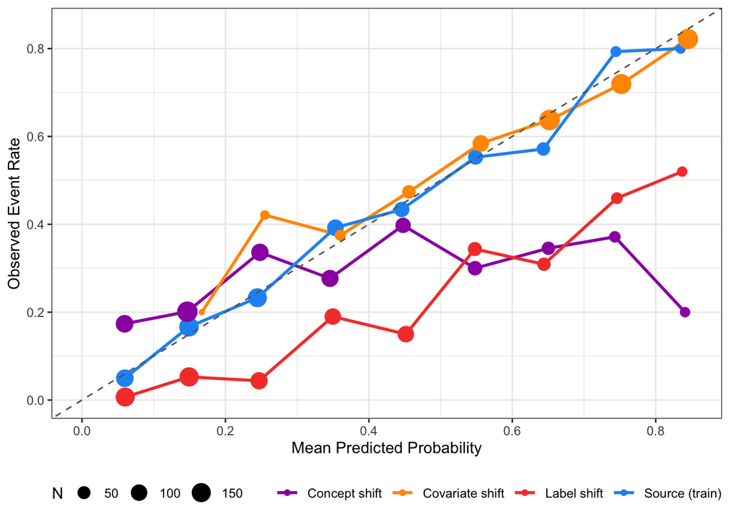

```r
set.seed(274)
n_shift <- 800

x_s  <- rnorm(n_shift)
y_s  <- rbinom(n_shift, 1, plogis(-1 + 1.2*x_s))

lr_source <- glm(y_s ~ x_s, family=binomial, data=tibble(y_s, x_s))

make_cal_shift <- function(x_new, y_new, label) {
  p_hat <- predict(lr_source, newdata=tibble(x_s=x_new), type="response")
  tibble(pred=p_hat, obs=y_new) %>%
    mutate(bin=cut(pred, breaks=seq(0,1,0.1), include.lowest=TRUE)) %>%
    group_by(bin) %>%
    summarise(mean_pred=mean(pred), mean_obs=mean(obs), n=n(), .groups="drop") %>%
    mutate(domain=label)
}

x_cov <- rnorm(n_shift, mean=1.5, sd=0.7)
y_cov <- rbinom(n_shift, 1, plogis(-1 + 1.2*x_cov))

x_lab <- rnorm(n_shift)
y_lab <- rbinom(n_shift, 1, plogis(-2.2 + 1.2*x_lab))

x_con <- rnorm(n_shift)
y_con <- rbinom(n_shift, 1, plogis(-1 + 0.3*x_con))

bind_rows(
  make_cal_shift(x_s,   y_s,   "Source (train)"),
  make_cal_shift(x_cov, y_cov, "Covariate shift"),
  make_cal_shift(x_lab, y_lab, "Label shift"),
  make_cal_shift(x_con, y_con, "Concept shift")
) %>%
  ggplot(aes(x=mean_pred, y=mean_obs, color=domain)) +
  geom_line(linewidth=1.0) + geom_point(aes(size=n)) +
  geom_abline(slope=1, intercept=0, linetype="dashed", color="gray40") +
  scale_color_manual(values=c("Source (train)"="#2196F3", "Covariate shift"="#FF9800",
                               "Label shift"="#F44336", "Concept shift"="#9C27B0")) +
  scale_x_continuous(limits=c(0,0.85)) + scale_y_continuous(limits=c(0,0.85)) +
  labs(x="Mean Predicted Probability", y="Observed Event Rate", color=NULL, size="N") +
  theme_bw() + theme(legend.position="bottom")
```

### 5.2 Diagnosing Shift from Metrics

| Cal. intercept $\alpha$ | Cal. slope $\beta$ | Most likely cause | Fix |
| --- | --- | --- | --- |
| Nonzero | Near 1 | Label shift | Intercept-only recalibration |
| Drifted | Drifted | Covariate shift | Logistic recalibration |
| Still off after correction | — | Concept shift | Model revision or retraining |

### 5.3 Connection to Readmission Project

Applying the Private-trained model to Medicare patients is primarily a **label shift** problem (higher baseline readmission rate) with some **covariate shift** (different patient mix).

## 6 Recalibration Methods

The general recalibration equation:

$$\text{logit}(\hat{y}_{\text{recal}}) = \hat{\alpha} + \hat{\beta} \cdot \text{logit}(\hat{y}_{\text{source}})$$

$\hat{\alpha}$ and $\hat{\beta}$ are estimated on a **labeled calibration set from the target domain**.

The `glm` code from the metrics section is already the recalibration engine — you just need to use the fitted values to generate corrected probabilities.

| Level | What you fix | Code |
| --- | --- | --- |
| **1. Intercept-only** | Mean shift only ($\beta = 1$ fixed) | `glm(y ~ offset(logit_p))` |
| **2. Logistic recalibration** | Mean + spread (= Platt scaling in ML) | `glm(y ~ logit_p)` |
| **3. Isotonic regression** | Any monotone miscalibration | `isoreg()` |

Start with Level 1. Only go deeper if diagnostics say you need to.

### 6.1 Full Recalibration Demo

```r
# ── Simulate a target calibration set (label shift: lower intercept) ──────────
set.seed(42)
n_cal  <- 400
x1_cal <- rnorm(n_cal); x2_cal <- rnorm(n_cal); x3_cal <- rbinom(n_cal,1,0.4)
y_cal  <- rbinom(n_cal, 1, plogis(-2.5 + 0.8*x1_cal + 0.6*x2_cal + 0.5*x3_cal))

# Source model predictions on calibration set
p_misc_cal   <- plogis(qlogis(
  predict(lr_fit, newdata=tibble(x1=x1_cal,x2=x2_cal,x3=x3_cal), type="response")
) * 0.3 - 1.5)

logit_p_cal  <- qlogis(pmin(pmax(p_misc_cal, 1e-6), 1-1e-6))
logit_p_test <- qlogis(pmin(pmax(p_misc,     1e-6), 1-1e-6))

# ── Level 1: Intercept-only ───────────────────────────────────────────────────
m_int    <- glm(y_cal ~ offset(logit_p_cal), family=binomial)
p_recal1 <- plogis(coef(m_int)[["(Intercept)"]] + logit_p_test)

# ── Level 2: Logistic recalibration (Platt scaling) ──────────────────────────
m_lr     <- glm(y_cal ~ logit_p_cal, family=binomial)
p_recal2 <- plogis(coef(m_lr)[["(Intercept)"]] +
                   coef(m_lr)[["logit_p_cal"]] * logit_p_test)

cat(sprintf("Level 1 — Intercept-only:  alpha = %.3f  (beta fixed = 1)\n",
            coef(m_int)[["(Intercept)"]]))
```

```
Level 1 — Intercept-only:  alpha = 0.100  (beta fixed = 1)
```

```r
cat(sprintf("Level 2 — Logistic recal:  alpha = %.3f, beta = %.3f\n",
            coef(m_lr)[["(Intercept)"]], coef(m_lr)[["logit_p_cal"]]))
```

```
Level 2 — Logistic recal:  alpha = 3.824, beta = 2.951
```

```r
# ── Level 3: Isotonic regression ─────────────────────────────────────────────
iso_fit  <- isoreg(p_misc_cal, y_cal)
ord      <- order(p_misc_cal)
p_recal3 <- approx(p_misc_cal[ord], iso_fit$yf[ord], xout=p_misc,
                   method="constant", rule=2, ties=mean)$y
```

### 6.2 Before vs. After: Reliability Diagrams

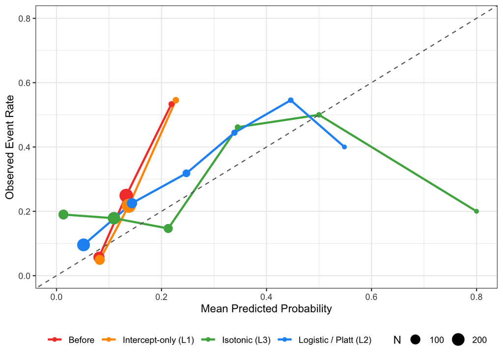

```r
bind_rows(
  make_cal_df(p_misc,   y_test, "Before"),
  make_cal_df(p_recal1, y_test, "Intercept-only (L1)"),
  make_cal_df(p_recal2, y_test, "Logistic / Platt (L2)"),
  make_cal_df(p_recal3, y_test, "Isotonic (L3)")
) %>%
  ggplot(aes(x=mean_pred, y=mean_obs, color=model)) +
  geom_line(linewidth=1.0) + geom_point(aes(size=n)) +
  geom_abline(slope=1, intercept=0, linetype="dashed", color="gray40") +
  scale_color_manual(values=c("Before"="#F44336","Intercept-only (L1)"="#FF9800",
                               "Logistic / Platt (L2)"="#2196F3","Isotonic (L3)"="#4CAF50")) +
  scale_x_continuous(limits=c(0,0.8)) + scale_y_continuous(limits=c(0,0.8)) +
  labs(x="Mean Predicted Probability", y="Observed Event Rate", color=NULL, size="N") +
  theme_bw() + theme(legend.position="bottom")
```

### 6.3 Before vs. After: Metrics

```r
brier_fn <- function(p, y) mean((p-y)^2)

models <- list("Before"=p_misc, "Intercept-only"=p_recal1,
               "Logistic / Platt"=p_recal2, "Isotonic"=p_recal3)

tibble(
  Method        = names(models),
  AUROC         = sapply(models, function(p) auroc(p,    y_test)) %>% round(3),
  `Brier Score` = sapply(models, function(p) brier_fn(p, y_test)) %>% round(4),
  `Cal. alpha`  = sapply(models, function(p) cx_int(p,   y_test)) %>% round(3),
  `Cal. beta`   = sapply(models, function(p) cx_slp(p,   y_test)) %>% round(3),
  ICI           = sapply(models, function(p) ici_fn(p,   y_test)) %>% round(4)
) %>% knitr::kable(align=c("l","r","r","r","r","r"))
```

| Method | AUROC | Brier Score | Cal. alpha | Cal. beta | ICI |
| --- | --- | --- | --- | --- | --- |
| Before | 0.732 | 0.1525 | 0.589 | 2.574 | 0.0902 |
| Intercept-only | 0.732 | 0.1505 | 0.488 | 2.574 | 0.0840 |
| Logistic / Platt | 0.732 | 0.1422 | 0.522 | 0.872 | 0.0630 |
| Isotonic | 0.529 | 0.1691 | 0.521 | -0.006 | 0.1061 |

**NoteML connection: temperature scaling**

> **Janssen et al. (2008):** Simple recalibration improved calibration to a similar extent as full model revision. More complex updating should only be attempted with large validation samples.

## 7 Transfer Learning

Recalibration is transfer learning’s simplest special case. Both answer the same question: *how much of the source model can be trusted in the target domain?*

### 7.1 The Spectrum

[figure not shown]

```r
tibble(
  level      = rep(5:1, 2),
  discipline = rep(c("Statistical epidemiology","Machine learning"), each=5),
  method     = c(
    "Full redevelopment", "Model extension\n(add predictors)",
    "Model revision\n(refit coefficients)", "Logistic recalibration\n(slope + intercept)",
    "Intercept-only\n(mean shift only)",
    "Pretrain from scratch", "Fine-tune deep layers",
    "Fine-tune last layer", "Platt scaling /\nvector scaling",
    "Temperature scaling"
  )
) %>%
  mutate(x_pos = ifelse(discipline=="Statistical epidemiology", 1, 2)) %>%
  ggplot(aes(x=x_pos, y=level)) +
  geom_tile(aes(fill=factor(level)), width=0.85, height=0.8, alpha=0.25, color="gray70") +
  geom_text(aes(label=method), size=3.0, lineheight=0.9) +
  geom_text(data=tibble(x_pos=c(1,2), y=5.7,
                         label=c("Statistical epidemiology","Machine learning")),
            aes(x=x_pos, y=y, label=label), fontface="bold", size=3.5, inherit.aes=FALSE) +
  annotate("text", x=2.65, y=5.0, label="Small target\ndata needed", size=2.8, color="gray30") +
  annotate("segment", x=2.72, xend=2.72, y=4.6, yend=1.4,
           arrow=arrow(ends="both", length=unit(0.15,"cm"), type="closed"),
           color="gray50", linewidth=0.5) +
  annotate("text", x=2.65, y=1.0, label="Large target\ndata needed", size=2.8, color="gray30") +
  scale_fill_brewer(palette="Blues") +
  scale_x_continuous(limits=c(0.4, 3.1)) + scale_y_continuous(limits=c(0.5, 6.0)) +
  labs(title="The Transfer Learning Spectrum", subtitle="Same problem, two vocabularies") +
  theme_void() +
  theme(legend.position="none",
        plot.title=element_text(face="bold", size=13, hjust=0.5),
        plot.subtitle=element_text(size=10, hjust=0.5, color="gray40"))
```

### 7.2 One Equation, Two Fields

**Statistical recalibration:**
$$\text{logit}(\hat{y}_{\text{recal}}) = \hat{\alpha} + \hat{\beta} \cdot \text{logit}(\hat{y}_{\text{source}})$$

**ML temperature scaling** (Guo et al., ICML 2017):
$$P(y \mid x)_{\text{recal}} = \text{softmax}(z / T)$$

These are the **same operation.** Dividing logits by $T$ is equivalent to $\hat{\beta} = 1/T$. Temperature scaling is intercept-free logistic recalibration — it corrects spread but not mean shift.

### 7.3 Fine-Tuning as Deep Recalibration

| Strategy | What you update | ML analog | Statistical analog |
| --- | --- | --- | --- |
| Freeze backbone, retrain head | Output layer only | Fine-tune last layer | Logistic recalibration |
| Unfreeze deeper layers | Internal representations | Fine-tune deep layers | Model revision |
| Train from scratch | Everything | Pretrain from scratch | Full redevelopment |

### 7.4 A Cautionary Note: Negative Transfer

- More complex transfer is **not always better.**
- Guo et al. (2022): sophisticated domain generalization methods **failed to beat simple intercept-only recalibration** in temporal shift settings.
- Always start simple. Let diagnostics ($\alpha$, $\beta$, ICI, AUROC) tell you whether to go deeper.

### 7.5 Decision Guide

```r
tibble(
  `Diagnostic result` = c("alpha != 0, beta ~ 1", "alpha != 0, beta != 1",
                           "alpha, beta OK but ICI still high",
                           "AUROC also degraded", "Concept shift"),
  `Shift type`        = c("Label shift", "Covariate shift",
                           "Non-linear miscalibration",
                           "Feature distribution change", "Concept shift"),
  `Strategy`          = c("Intercept-only", "Logistic recalibration",
                           "Isotonic regression",
                           "Fine-tune output layer", "Revise or retrain"),
  `Target N needed`   = c("~100-300", "~300-500", ">1,000",
                           ">1,000 labeled", "Large labeled set")
) %>% knitr::kable(align=c("l","l","l","r"))
```

Table 3: Use calibration diagnostics to choose a strategy before committing to a method.

| Diagnostic result | Shift type | Strategy | Target N needed |
| --- | --- | --- | --- |
| alpha != 0, beta ~ 1 | Label shift | Intercept-only | ~100-300 |
| alpha != 0, beta != 1 | Covariate shift | Logistic recalibration | ~300-500 |
| alpha, beta OK but ICI still high | Non-linear miscalibration | Isotonic regression | >1,000 |
| AUROC also degraded | Feature distribution change | Fine-tune output layer | >1,000 labeled |
| Concept shift | Concept shift | Revise or retrain | Large labeled set |

> **Bottom line:** Recalibration handles the easy cases cheaply. Transfer learning handles the hard cases at greater cost. Your diagnostics tell you which case you are in.